# Intro to R

## Slide 1: Overview

- What is R?
- Installing and Setting up R
- Data Types
- Data Structures
- reading in Data
- Data Sources

## Slide 2: What is R and what can I do with it?

- analysis
- Summary Statics (mean, median mode, range)
- Analysis of statistical significance (p tests and t tests, ANOVA)
- Prediction (regression models, decision trees, Random Forest)
- Text analysis

## Slide 3: What is R and what can I do with it?

- visualize data statically

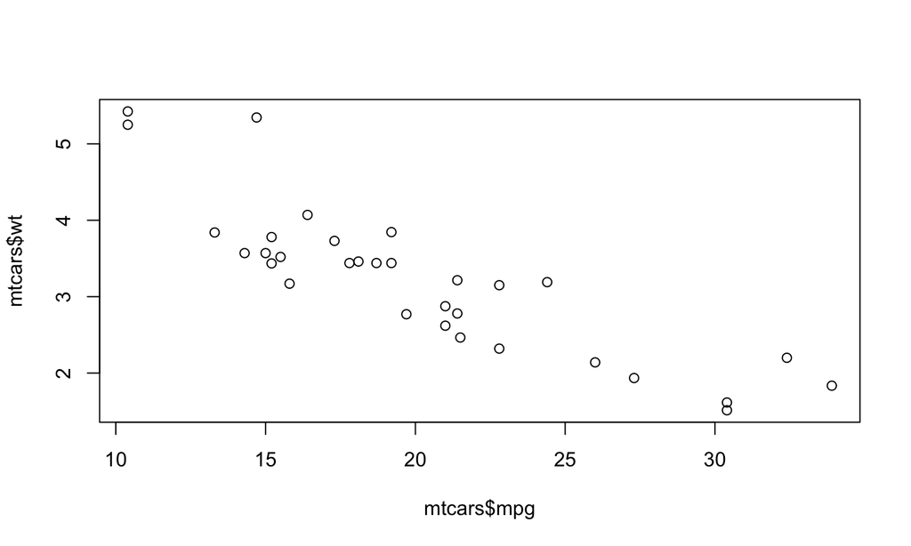

```r
plot(mtcars$mpg, mtcars$wt)
```

* visualize data interactively

## Slide 4: What is R and what can I do with it?

- build reports and presentations
- this presentation
- create MS Word and PPT documents [link] (https://davidgohel.github.io/ReporteRs/gettingstarted.html)

## Slide 5: What is R and what can I do with it?

- data products [link] (http://www.showmeshiny.com/)

## Slide 6: Getting started

- downloading R: [link] (http://cran.us.r-project.org/)
- RStudio: [link] (https://www.rstudio.com/products/rstudio/download/)

## Slide 7: Packages

- What are packages?
- installing and attaching packages

```r
install.packages("package_name")
library(package_name)
```

You will also see:

```r
require(package_name)
```

However it is not a good idea to use it. If it is not able to attach the desired package, you won't get an error until you try to use it. It is better to know at the beginning.

## Slide 8: Built in Datasets

R has a lot of built in datasets that you can use to practice on. You can see a full list of them by typing:

```r
library(help = "datasets")
```

You can actually do this for any package. (Try to get used to reading documentation. It will become your best friend. Also, stackoverflow).

## Slide 9a: Data Types (1 of 2)

- Character

```
## [1] "Hello Tech Ladies"
```

- numeric

```
## [1] 6 6 4 6 8 6
```

```
## [1] 2.620 2.875 2.320 3.215 3.440 3.460
```

## Slide 9b: Data Types (2 of 2)

- date

```
## [1] "2015-08-07"
```

- factor (data frames) (we'll talk more about these later)

```
## [1] setosa     versicolor virginica
## Levels: setosa versicolor virginica
```

## Slide 10: Data Structures

- vectors
- data frames
- lists

## Slide 11: Vectors

- set of data points
- can be character, integer, numeric, dates
- can only be one of the above

## Slide 12: Creating Vectors

- c() function

```r
c(5, 6, 7, 8)
```

```
## [1] 5 6 7 8
```

```r
c("Christina", "Leah", "Shanoon", "Adriana")
```

```
## [1] "Christina" "Leah"      "Shanoon"   "Adriana"
```

- words or characters must be enclosed in quotations otherwise R will complain
- capitalization is important

## Slide 13a: Examples of c()

- used to pass multiple arguments when a function only takes one. i.e.

```r
subset(mtcars, select = wt)
subset(mtcars, select = c("wt", "carb"))
```

## Slide 13b: Examples of c()

- useful when visualizing data to set color or other parameters

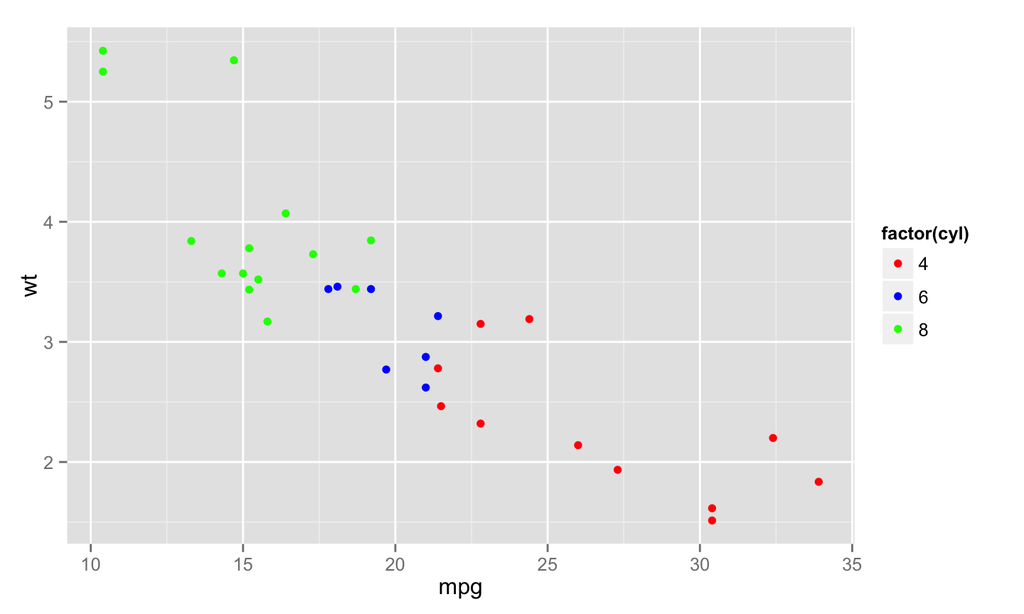

```r
cyl_col <- c("red", "blue", "green")
qplot(mpg, wt, data = mtcars, colour = factor(cyl)) +
scale_colour_manual(values = cyl_col)
```

## Slide 14: Side Trip: Variables

- assigning vectors, data frames and lists to variables allows us to manipulate them

```r
tech_ladies <- c("Christina", "Leah", "Shanoon", "Adriana")
tech_ladies2 = c("Christina", "Leah", "Shanoon", "Adriana")
```

- <- vs =
- when you assign a variable, R doesn't return anything
- you can see what is in a variable by typing its name

```r
tech_ladies
```

```
## [1] "Christina" "Leah"      "Shanoon"   "Adriana"
```

## Slide 15: Side Trip: Variables

- careful not to accidently change your variables

```r
tech_ladies <- "Stephen"
tech_ladies
```

```
## [1] "Stephen"
```

## Slide 16a: Modifying Vectors (1 of 2)

- add to a vector with c()

```r
tech_ladies2 <- c(tech_ladies2, "Maria")
```

- change a value

```r
tech_ladies2[3] <- "Sarah"
tech_ladies2
```

```
## [1] "Christina" "Leah"      "Sarah"     "Adriana"   "Maria"
```

## Slide 16b: Modifying Vectors (2 of 2)

- delete a value (slightly more complicated)

```r
remove <- "Adriana"
tech_ladies2 <- tech_ladies2[! tech_ladies2 %in% remove]
tech_ladies2
```

```
## [1] "Christina" "Leah"      "Sarah"     "Maria"
```

## Slide 17: Data Frames

- ordered collection of vectors
- columns are the variables or attributes in your data set
- rows are the observations
- can hold multiple types of data (i.e. characters, integers, numbers and dates)

```
##                    mpg cyl disp  hp drat    wt  qsec vs am gear carb
## Mazda RX4         21.0   6  160 110 3.90 2.620 16.46  0  1    4    4
## Mazda RX4 Wag     21.0   6  160 110 3.90 2.875 17.02  0  1    4    4
## Datsun 710        22.8   4  108  93 3.85 2.320 18.61  1  1    4    1
## Hornet 4 Drive    21.4   6  258 110 3.08 3.215 19.44  1  0    3    1
## Hornet Sportabout 18.7   8  360 175 3.15 3.440 17.02  0  0    3    2
## Valiant           18.1   6  225 105 2.76 3.460 20.22  1  0    3    1
```

## Slide 18: Creating Data Frames:

- data.frame(x = x, y = y)
- as.data.frame(table)
- read.csv()

```r
a <- data.frame(x = tech_ladies2, y = c(6, 2, 8, 4))
## x and y must have the same length
a
```

```
##           x y
## 1 Christina 6
## 2      Leah 2
## 3     Sarah 8
## 4     Maria 4
```

```r
hec <- as.data.frame(HairEyeColor)
#dat <- read.csv() ## we'll see this in a bit.
```

## Slide 19: Factor Variables

- specific to data frames
- special because sometimes they are required, sometime they interfere.

```r
str(hec)
```

```
## 'data.frame':    32 obs. of  4 variables:
##  $ Hair: Factor w/ 4 levels "Black","Brown",..: 1 2 3 4 1 2 3 4 1 2 ...
##  $ Eye : Factor w/ 4 levels "Brown","Blue",..: 1 1 1 1 2 2 2 2 3 3 ...
##  $ Sex : Factor w/ 2 levels "Male","Female": 1 1 1 1 1 1 1 1 1 1 ...
##  $ Freq: num  32 53 10 3 11 50 10 30 10 25 ...
```

## Slide 20a: Subsetting DF (1 of 3)

- subset(data, boolean, select = desired_columns)
- [row, column]
- [row == x, column == y]

```r
head(hec)
```

```
##    Hair   Eye  Sex Freq
## 1 Black Brown Male   32
## 2 Brown Brown Male   53
## 3   Red Brown Male   10
## 4 Blond Brown Male    3
## 5 Black  Blue Male   11
## 6 Brown  Blue Male   50
```

## Slide 20b: Subsetting DF (2 of 3)

```r
subset(hec, Hair == "Red")
```

```
##    Hair   Eye    Sex Freq
## 3   Red Brown   Male   10
## 7   Red  Blue   Male   10
## 11  Red Hazel   Male    7
## 15  Red Green   Male    7
## 19  Red Brown Female   16
## 23  Red  Blue Female    7
## 27  Red Hazel Female    7
## 31  Red Green Female    7
```

```r
subset(hec, select = "Eye")
```

```
##      Eye
## 1  Brown
## 2  Brown
## 3  Brown
## 4  Brown
## 5   Blue
## 6   Blue
## 7   Blue
## 8   Blue
## 9  Hazel
## 10 Hazel
## 11 Hazel
## 12 Hazel
## 13 Green
## 14 Green
```

[output cut: 18 more lines]

## Slide 20c: Subsetting DF (3 of 3)

```r
hec[5,3]
```

```
## [1] Male
## Levels: Male Female
```

```r
hec[, "Sex"]
```

```
##  [1] Male   Male   Male   Male   Male   Male   Male   Male   Male   Male
## [11] Male   Male   Male   Male   Male   Male   Female Female Female Female
## [21] Female Female Female Female Female Female Female Female Female Female
## [31] Female Female
## Levels: Male Female
```

## Slide 21a: Lists (1 of 2)

- like vectors but can have distinct data types including data frames and other lists
- useful for splitting and iterating over

```r
hec_split <- split(hec, hec$Eye)
str(hec_split)
```

```
## List of 4
##  $ Brown:'data.frame':   8 obs. of  4 variables:
##   ..$ Hair: Factor w/ 4 levels "Black","Brown",..: 1 2 3 4 1 2 3 4
##   ..$ Eye : Factor w/ 4 levels "Brown","Blue",..: 1 1 1 1 1 1 1 1
##   ..$ Sex : Factor w/ 2 levels "Male","Female": 1 1 1 1 2 2 2 2
##   ..$ Freq: num [1:8] 32 53 10 3 36 66 16 4
##  $ Blue :'data.frame':   8 obs. of  4 variables:
##   ..$ Hair: Factor w/ 4 levels "Black","Brown",..: 1 2 3 4 1 2 3 4
##   ..$ Eye : Factor w/ 4 levels "Brown","Blue",..: 2 2 2 2 2 2 2 2
##   ..$ Sex : Factor w/ 2 levels "Male","Female": 1 1 1 1 2 2 2 2
##   ..$ Freq: num [1:8] 11 50 10 30 9 34 7 64
##  $ Hazel:'data.frame':   8 obs. of  4 variables:
##   ..$ Hair: Factor w/ 4 levels "Black","Brown",..: 1 2 3 4 1 2 3 4
##   ..$ Eye : Factor w/ 4 levels "Brown","Blue",..: 3 3 3 3 3 3 3 3
##   ..$ Sex : Factor w/ 2 levels "Male","Female": 1 1 1 1 2 2 2 2
##   ..$ Freq: num [1:8] 10 25 7 5 5 29 7 5
##  $ Green:'data.frame':   8 obs. of  4 variables:
##   ..$ Hair: Factor w/ 4 levels "Black","Brown",..: 1 2 3 4 1 2 3 4
##   ..$ Eye : Factor w/ 4 levels "Brown","Blue",..: 4 4 4 4 4 4 4 4
##   ..$ Sex : Factor w/ 2 levels "Male","Female": 1 1 1 1 2 2 2 2
##   ..$ Freq: num [1:8] 3 15 7 8 2 14 7 8
```

## Slide 21b: Lists (2 of 2)

```r
tots <- lapply(hec_split, function(x) sum(x$Freq))
tots
```

```
## $Brown
## [1] 220
##
## $Blue
## [1] 215
##
## $Hazel
## [1] 93
##
## $Green
## [1] 64
```

## Slide 22: Reading in data:

- read.csv()

```r
pur <- read.csv("~/Documents/data\ files/Purchase_order_FY15.csv", stringsAsFactors = FALSE)
str(pur)
```

```
## 'data.frame':    22664 obs. of  6 variables:
##  $ Agency...Agency           : chr  "EQUIPMENT LEASE - CAPITAL" "METROPOLITAN POLICE DEPARTMENT" "METROPOLITAN POLICE DEPARTMENT" "DEPARTMENT OF GENERAL SERVICES" ...
##  $ Commodity...Commodity     : chr  "9182930:CONSULTING SERVICES RELATED TO THE IMPLEMENTATION OF SOFTWARE" "9182930:CONSULTING SERVICES RELATED TO THE IMPLEMENTATION OF SOFTWARE" "9625800:Professional Services (Not Otherwise Classified)" "9582600:Construction Management Services" ...
##  $ Supplier...Common.Supplier: chr  "OST, Inc." "OST, Inc." "ABC TOWING INC" "Kramer Consulting Services PC" ...
##  $ Ordered.Date              : chr  "23-Oct-14" "25-Nov-14" "1-Oct-14" "28-Jan-15" ...
##  $ PO..                      : chr  "PO508160" "PO505678-V2" "PO505398" "PO514707" ...
##  $ PO.amount                 : chr  "29,932.80" "134,608.35" "37,500.00" "175,000.00" ...
```

## Slide 23a: Data Sets (1 of 2)

- DC Open Data [link] (http://data.octo.dc.gov/)
- NYC Open Data [link] (https://nycopendata.socrata.com/)
- Data.gov [link] (http://catalog.data.gov/dataset?groups=businessusa4208#topic=business_navigation)
- World Bank Data Catalog [link] (http://datacatalog.worldbank.org/)
- World Bank API [link] (http://data.worldbank.org/developers/data-catalog-api)
- UN Data [link] (https://data.un.org/DataMartInfo.aspx)
- Data Science Central (warehouse for data sets, many are the same as those above) [link] (http://www.datasciencecentral.com/profiles/blogs/the-free-big-data-sources-everyone-should-know)

## Slide 23b: Data Sets (2 of 2)

- KD nuggests (also a warehouse for sources of public data sets) [link] (http://www.kdnuggets.com/datasets/index.html)
- Quora (yet another warehouse) [link] (http://www.quora.com/Where-can-I-find-large-datasets-open-to-the-public)
- UCI Machine Learning Rpository [link] (http://archive.ics.uci.edu/ml/)
- The Guardian Data Blog (make data sets available) [link] (http://www.theguardian.com/data/all)

## Slide 24: Learning Resources/R Blogs:

- Rbloggers
- Stackoverflow
- Coursera Data Analysis and Statistical Inference
- DataCamp